# Statistics Lab 9 - Diagnostics Part 2

```r
library(tidyr)
library(readr)
library(dplyr)
library(stringr)
library(ggplot2)
```

# Question Set 1

For the next few questions, we will revisit the mtcars data set. Use the whole data set (do not subset).

## Question 1

Create the Pearson’s correlation between all the quantitative x-variables. What is the largest value in magnitude of the correlation among the x-variables?

```r
mtcars
```

| ...1 | mpg | cyl | disp | hp | drat | wt | qsec | vs | am | gear | carb |
| --- | --- | --- | --- | --- | --- | --- | --- | --- | --- | --- | --- |
| Mazda RX4 | 21.0 | 6 | 160.0 | 110 | 3.90 | 2.620 | 16.46 | 0 | 1 | 4 | 4 |
| Mazda RX4 Wag | 21.0 | 6 | 160.0 | 110 | 3.90 | 2.875 | 17.02 | 0 | 1 | 4 | 4 |
| Datsun 710 | 22.8 | 4 | 108.0 | 93 | 3.85 | 2.320 | 18.61 | 1 | 1 | 4 | 1 |
| Hornet 4 Drive | 21.4 | 6 | 258.0 | 110 | 3.08 | 3.215 | 19.44 | 1 | 0 | 3 | 1 |
| Hornet Sportabout | 18.7 | 8 | 360.0 | 175 | 3.15 | 3.440 | 17.02 | 0 | 0 | 3 | 2 |
| Valiant | 18.1 | 6 | 225.0 | 105 | 2.76 | 3.460 | 20.22 | 1 | 0 | 3 | 1 |
| Duster 360 | 14.3 | 8 | 360.0 | 245 | 3.21 | 3.570 | 15.84 | 0 | 0 | 3 | 4 |
| Merc 240D | 24.4 | 4 | 146.7 | 62 | 3.69 | 3.190 | 20.00 | 1 | 0 | 4 | 2 |
| Merc 230 | 22.8 | 4 | 140.8 | 95 | 3.92 | 3.150 | 22.90 | 1 | 0 | 4 | 2 |
| Merc 280 | 19.2 | 6 | 167.6 | 123 | 3.92 | 3.440 | 18.30 | 1 | 0 | 4 | 4 |

[output cut: 22 more lines]

```r
mtcars_corr_matrix <- cor(mtcars[-1])
mtcars_corr_matrix
```

```
            mpg        cyl       disp         hp        drat         wt        qsec         vs          am       gear        carb
mpg   1.0000000 -0.8521620 -0.8475514 -0.7761684  0.68117191 -0.8676594  0.41868403  0.6640389  0.59983243  0.4802848 -0.55092507
cyl  -0.8521620  1.0000000  0.9020329  0.8324475 -0.69993811  0.7824958 -0.59124207 -0.8108118 -0.52260705 -0.4926866  0.52698829
disp -0.8475514  0.9020329  1.0000000  0.7909486 -0.71021393  0.8879799 -0.43369788 -0.7104159 -0.59122704 -0.5555692  0.39497686
hp   -0.7761684  0.8324475  0.7909486  1.0000000 -0.44875912  0.6587479 -0.70822339 -0.7230967 -0.24320426 -0.1257043  0.74981247
drat  0.6811719 -0.6999381 -0.7102139 -0.4487591  1.00000000 -0.7124406  0.09120476  0.4402785  0.71271113  0.6996101 -0.09078980
wt   -0.8676594  0.7824958  0.8879799  0.6587479 -0.71244065  1.0000000 -0.17471588 -0.5549157 -0.69249526 -0.5832870  0.42760594
qsec  0.4186840 -0.5912421 -0.4336979 -0.7082234  0.09120476 -0.1747159  1.00000000  0.7445354 -0.22986086 -0.2126822 -0.65624923
vs    0.6640389 -0.8108118 -0.7104159 -0.7230967  0.44027846 -0.5549157  0.74453544  1.0000000  0.16834512  0.2060233 -0.56960714
am    0.5998324 -0.5226070 -0.5912270 -0.2432043  0.71271113 -0.6924953 -0.22986086  0.1683451  1.00000000  0.7940588  0.05753435
gear  0.4802848 -0.4926866 -0.5555692 -0.1257043  0.69961013 -0.5832870 -0.21268223  0.2060233  0.79405876  1.0000000  0.27407284
carb -0.5509251  0.5269883  0.3949769  0.7498125 -0.09078980  0.4276059 -0.65624923 -0.5696071  0.05753435  0.2740728  1.00000000
```

```r
mtcars_corr_matrix_r_sorted <- sort(abs(mtcars_corr_matrix))
mtcars_corr_matrix_r_sorted
```

```
  [1] 0.05753435 0.05753435 0.09078980 0.09078980 0.09120476 0.09120476 0.12570426 0.12570426 0.16834512 0.16834512 0.17471588 0.17471588 0.20602335 0.20602335 0.21268223 0.21268223
 [17] 0.22986086 0.22986086 0.24320426 0.24320426 0.27407284 0.27407284 0.39497686 0.39497686 0.41868403 0.41868403 0.42760594 0.42760594 0.43369788 0.43369788 0.44027846 0.44027846
 [33] 0.44875912 0.44875912 0.48028476 0.48028476 0.49268660 0.49268660 0.52260705 0.52260705 0.52698829 0.52698829 0.55092507 0.55092507 0.55491568 0.55491568 0.55556920 0.55556920
 [49] 0.56960714 0.56960714 0.58328700 0.58328700 0.59122704 0.59122704 0.59124207 0.59124207 0.59983243 0.59983243 0.65624923 0.65624923 0.65874789 0.65874789 0.66403892 0.66403892
 [65] 0.68117191 0.68117191 0.69249526 0.69249526 0.69961013 0.69961013 0.69993811 0.69993811 0.70822339 0.70822339 0.71021393 0.71021393 0.71041589 0.71041589 0.71244065 0.71244065
 [81] 0.71271113 0.71271113 0.72309674 0.72309674 0.74453544 0.74453544 0.74981247 0.74981247 0.77616837 0.77616837 0.78249579 0.78249579 0.79094859 0.79094859 0.79405876 0.79405876
 [97] 0.81081180 0.81081180 0.83244745 0.83244745 0.84755138 0.84755138 0.85216196 0.85216196 0.86765938 0.86765938 0.88797992 0.88797992 0.90203287 0.90203287 1.00000000 1.00000000
[113] 1.00000000 1.00000000 1.00000000 1.00000000 1.00000000 1.00000000 1.00000000 1.00000000 1.00000000
```

## Question 2

Create the linear model: wt + hp + wt*hp and look at the QQ-plot. In this plot, Normality seems like a reasonable assumption?

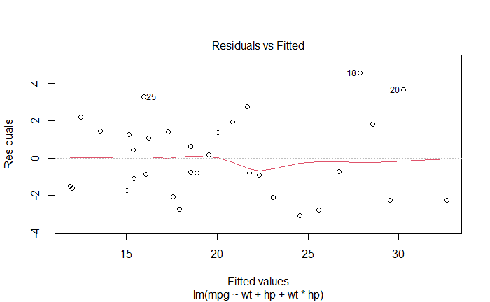

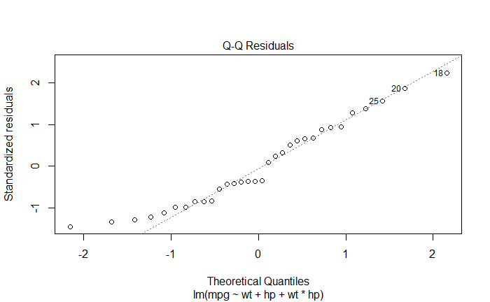

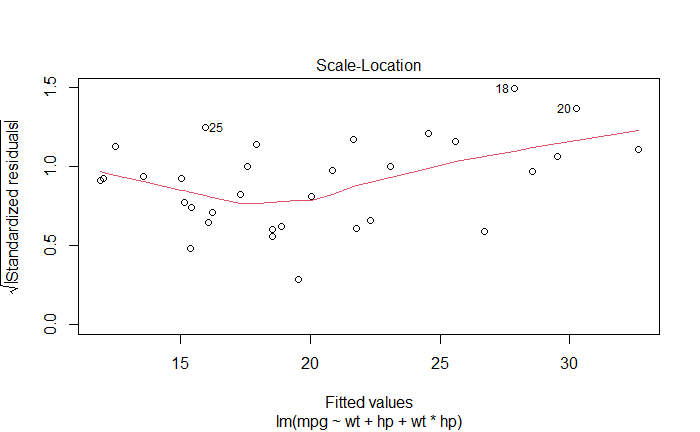

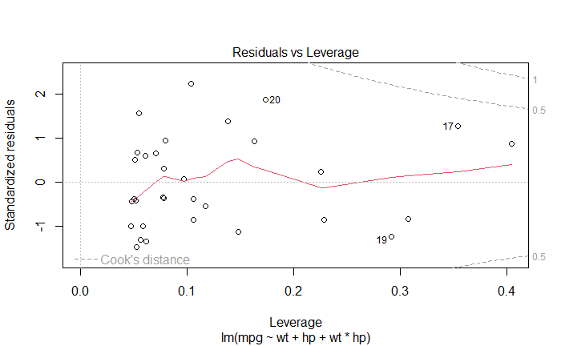

```r
mtcars_mlr1 <- lm(mpg ~ wt + hp + wt*hp, data = mtcars)
plot(mtcars_mlr1)
```

## Question 3

Using the model from above, create the residual plot. What would be your conclusion about the assumption of homogeneity of the variance?

Answer: Homogeneity of the variance appears appropriate since the spread of the residuals are fairly consistent.

## Question 4

We can use the residual plot to help us decide if the errors are Normally distributed.

Answer: False

# Question Set 2

For the rest of the problems, we will be using the cars2010 data set (this data set is a training data set, so you do not need to subset….use the entire data set).

```r
cars <- read_csv("https://raw.githubusercontent.com/IAA-Faculty/statistical_foundations/refs/heads/master/cars2010.csv")
```

## Question 5

Create the linear model with the following variables and calculate the Cook’s D statistic. What is the largest value for Cook’s D (recall that FE..Fuel Economy is the response variable)? Keep answer accuracy to three decimal places.

```r
cars_mlr <- lm(FE ~ EngDispl + C(Transmission) + C(AirAspirationMethod) + C(TransLockup) + C(TransCreeperGear) + C(DriveDesc) + C(IntakeValvePerCyl) + C(CarlineClassDesc) + C(VarValveLift), data = cars)

cars_cook <- cooks.distance(cars_mlr)
sort(cars_cook, decreasing = TRUE)
```

[output not shown]

## Question 6

Now let’s use the Hat values to identify influential points and external studentized residuals to identify outliers. How many observations are above the Hat value cutoff AND has a magnitude above 3?

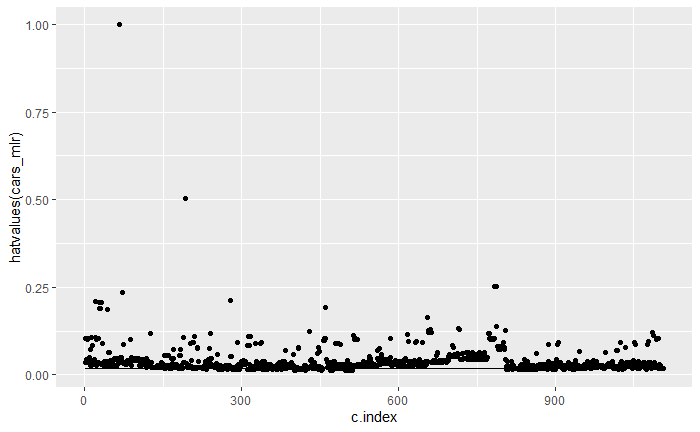

```r
c.index = seq(1, nrow(cars))

h_threshold <- 20/nrow(cars)
h_bool = hatvalues(cars_mlr)>h_threshold
h_plot = ggplot(cars_mlr, aes(x = c.index, y=hatvalues(cars_mlr))) + geom_point() + geom_line(y=h_threshold)
plot(h_plot)
```

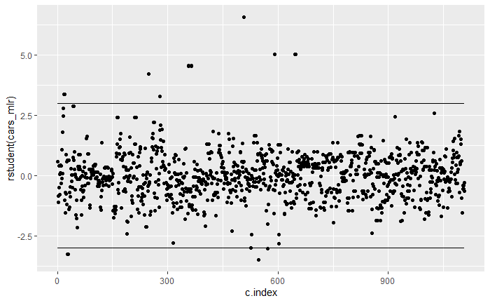

```r
rstudent_bool = abs(rstudent(cars_mlr))>3
rstudent_plot = ggplot(cars_mlr, aes(x = c.index, y=rstudent(cars_mlr))) + geom_point() + geom_line(y=3) + geom_line(y=-3)
plot(rstudent_plot)
```

```r
both_bool = h_bool & rstudent_bool
num_influence = sum(both_bool)
num_influence
```

```
[1] 14
```